# Universidad de Costa Rica Estadística Espacial

Proyecto 2

Fabián Hernández Fiorella Laurito

## Introducción

[figure not shown]

## Resultados

Importación de capas

```r
#Cantones
Cantones.sf <- sf::st_read("Cantones_de_Costa_Rica.shp")
```

```
  Reading layer `Cantones_de_Costa_Rica' from data source `C:\Users\UNIVERSAL\Documents\Espacial\Proyecto 2\Cantones_de_Costa_Rica.shp' using driver `ESRI Shapefile'
  Simple feature collection with 81 features and 5 fields
  geometry type:  MULTIPOLYGON
  dimension:      XY
  bbox:           xmin: 156156.4 ymin: 608835 xmax: 658937.7 ymax: 1241131
  epsg (SRID):    NA
  proj4string:    +proj=tmerc +lat_0=0 +lon_0=-84 +k=0.9999 +x_0=500000 +y_0=0 +ellps=WGS84 +units=m +no_defs
```

```r
Cantones.sf<-Cantones.sf %>% sf::st_transform(crs = sf::st_crs(4326))

path <- "Cantones_de_Costa_Rica.shp"
Cantones <- shapefile(path)

#GAM
GAM.sf <- sf::st_read("wms.kml")
```

```
  Reading layer `GAM:GAM' from data source `C:\Users\UNIVERSAL\Documents\Espacial\Proyecto 2\wms.kml' using driver `KML'
  Simple feature collection with 2 features and 2 fields
  geometry type:  GEOMETRYCOLLECTION
  dimension:      XY
  bbox:           xmin: -84.46879 ymin: 9.742855 xmax: -83.76052 ymax: 10.15924
  epsg (SRID):    4326
  proj4string:    +proj=longlat +datum=WGS84 +no_defs
```

```r
GAM.sf<-sf::st_collection_extract(GAM.sf, "POLYGON")

GAM<-as(GAM.sf, 'Spatial')
GAM2 <- spTransform(GAM, CRS("+proj=tmerc +lat_0=0 +lon_0=-84 +k=0.9999 +x_0=500000 +y_0=0 +ellps=WGS84 +units=m +no_defs"))

Cantones.GAM <- crop(Cantones, GAM2)

Cantones.GAM.sf<-sf::st_as_sf(Cantones.GAM)

Cantones.GAM.sf<-Cantones.GAM.sf %>% sf::st_transform(crs = sf::st_crs(4326))
Cantones.GAM<-as(Cantones.GAM.sf, 'Spatial') #cambiar crs en sp

#Hospitales
hospitales_gam<-read.csv("hospitales-gam.csv",sep=",",fileEncoding = "UTF-8")
clinicas<-read.csv("clinica.csv",sep=";",fileEncoding = "UTF-8")

distancias<-read.csv("distance.csv",sep=",",fileEncoding = "UTF-8")

hospital_cercano<-distancias %>%
  group_by(IDC,IDH) %>%
  summarise(distancia =sum(Distancia) ) %>%
  filter(distancia==min(distancia))

#Clinicas y distancia a hospital más cercano

clinicas_distancia<-clinicas %>%
  left_join(hospital_cercano,by = c("IDT"="IDC"))

coordinates(clinicas_distancia)=~Longitude+Latitude
zero <- zerodist(clinicas_distancia)

projection(clinicas_distancia)=projection(Cantones.GAM)

#clinicas_distancia.sf<-sf::st_as_sf(clinicas_distancia)
#clinicas_distancia.sf<-clinicas_distancia.sf %>% sf::st_transform(crs = sf::st_crs(4326))
#clinicas_GAM <- st_intersects(clinicas_distancia.sf,Cantones.GAM.sf)

clinicas_GAM <- over(clinicas_distancia,Cantones.GAM)



clinicas_distancia$over <- clinicas_GAM$OBJECTID

data.clinicas.distancia <- clinicas_distancia[!is.na(clinicas_distancia$over),]
data.clinicas.distancia.sf<-sf::st_as_sf(data.clinicas.distancia)


data.clinicas.distancia
```

```
  class       : SpatialPointsDataFrame
  features    : 488
  extent      : -84.31883, -83.85667, 9.798611, 10.04519  (xmin, xmax, ymin, ymax)
  crs         : +proj=longlat +datum=WGS84 +no_defs +ellps=WGS84 +towgs84=0,0,0
  variables   : 11
  names       : IDT, Provincia,   Canton,                     Distrito,            Creacion, COD_PROV, COD_CANT, COD_DIST, IDH, distancia, over
  min values  :   1,  Alajuela, Alajuela, Aguacaliente (San Francisco), 0000-00-00 00:00:00,        1,        1,        1,   1,         0,   11
  max values  : 500,  San José,    Tibás,                       Zapote,   12/28/16 08:31 PM,        4,       18,       13,  12,     19419,   80
```

```r
#Hospitales

coordinates(hospitales_gam)=~Longitude+Latitude
projection(hospitales_gam)=projection(Cantones.GAM)
hospitales_gam.sf<-sf::st_as_sf(hospitales_gam)
```

### Mapeo de centros médicos

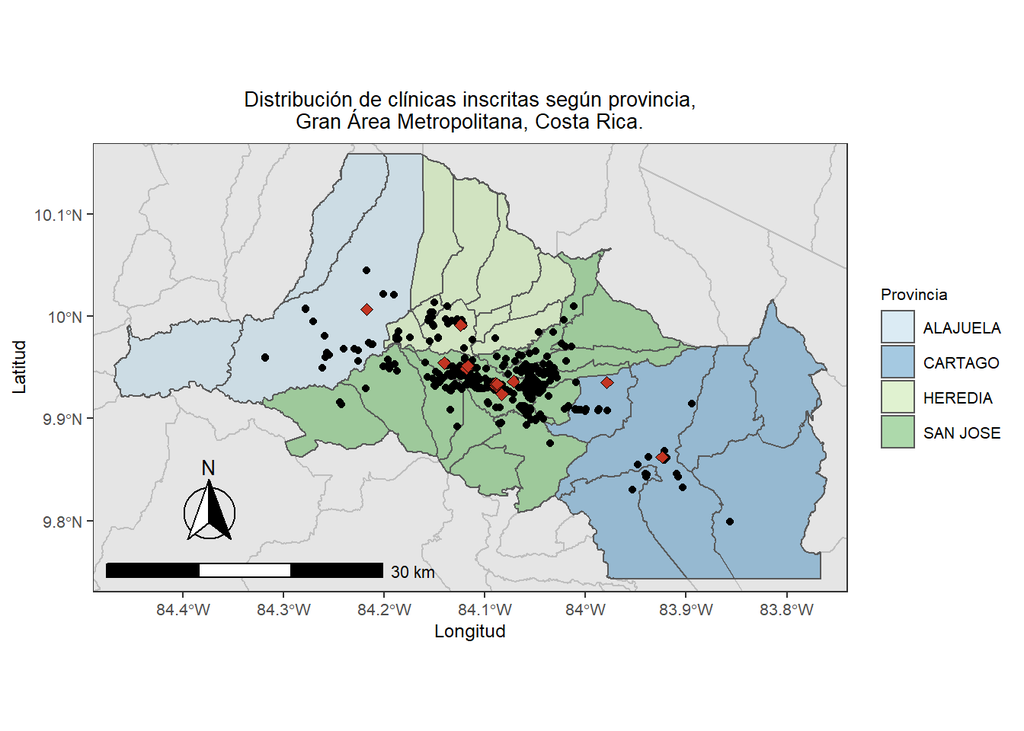

```r
ggplot() +
  geom_sf(data = Cantones.sf,
            colour="gray") +
    geom_sf(data = Cantones.GAM.sf,aes(fill=NOM_PROV), alpha=0.4) +
  geom_sf(data = data.clinicas.distancia.sf)+
  geom_sf(data = hospitales_gam.sf,shape = 23,fill="#C33522",size=2)+
  ggtitle("Distribución de clínicas inscritas según provincia,\n Gran Área Metropolitana, Costa Rica. ")+
  scale_fill_brewer(palette = "Paired"
                    , drop = FALSE,
                    guide_legend(title="Provincia"))+
   theme_bw()+
  theme(legend.title = element_text(size=8),
        legend.text = element_text(size=8),
        plot.title = element_text(hjust = 0.5, size=10),
        axis.title = element_text(size = 9),
        axis.text =  element_text(size = 8))+
  annotation_north_arrow(location = "bl", which_north = "true",
        pad_x = unit(0.5, "in"), pad_y = unit(0.3, "in"),
        style = north_arrow_fancy_orienteering) +
  annotation_scale(location = "bl", width_hint = 0.4)+
  xlab("Longitud") + ylab("Latitud")+
    coord_sf(xlim = c(-84.49, -83.74), ylim = c(9.73, 10.17), expand = FALSE)
```

### Estimación de la intensidad

#### Kernel y ancho de banda

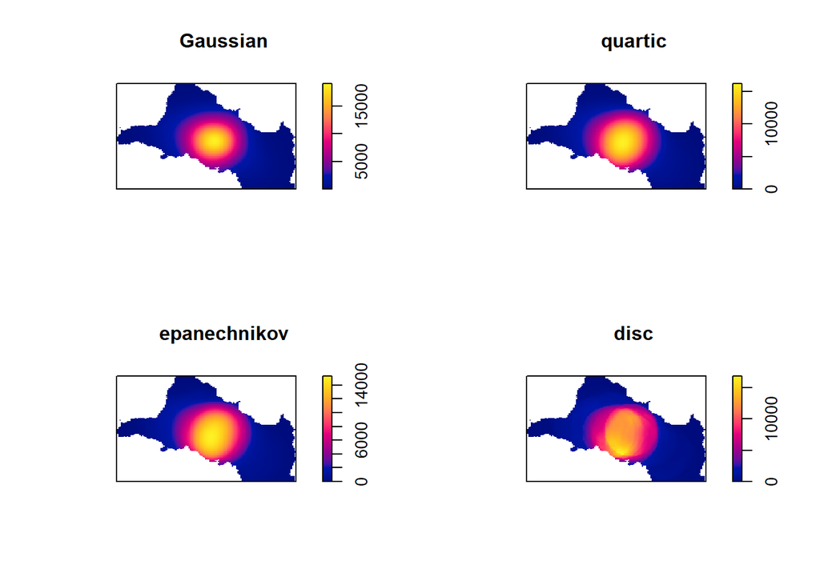

```r
par(mfrow=c(2,2))
plot(density(xy.ppp), main="Gaussian")
plot(density(xy.ppp, kernel="quartic"), main="quartic")
plot(density(xy.ppp, kernel="epanechnikov"),main="epanechnikov")
plot(density(xy.ppp, kernel="disc"),main="disc")
```

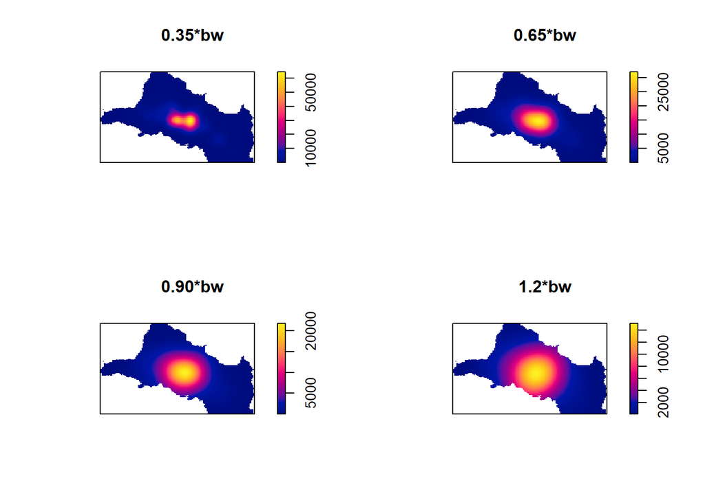

```r
par(mfrow=c(2,2))
plot(density(xy.ppp, adjust=0.35), main="0.35*bw")
plot(density(xy.ppp, adjust=0.65), main="0.65*bw")
plot(density(xy.ppp, adjust=0.90), main="0.90*bw")
plot(density(xy.ppp, adjust=1.2), main="1.2*bw")
```

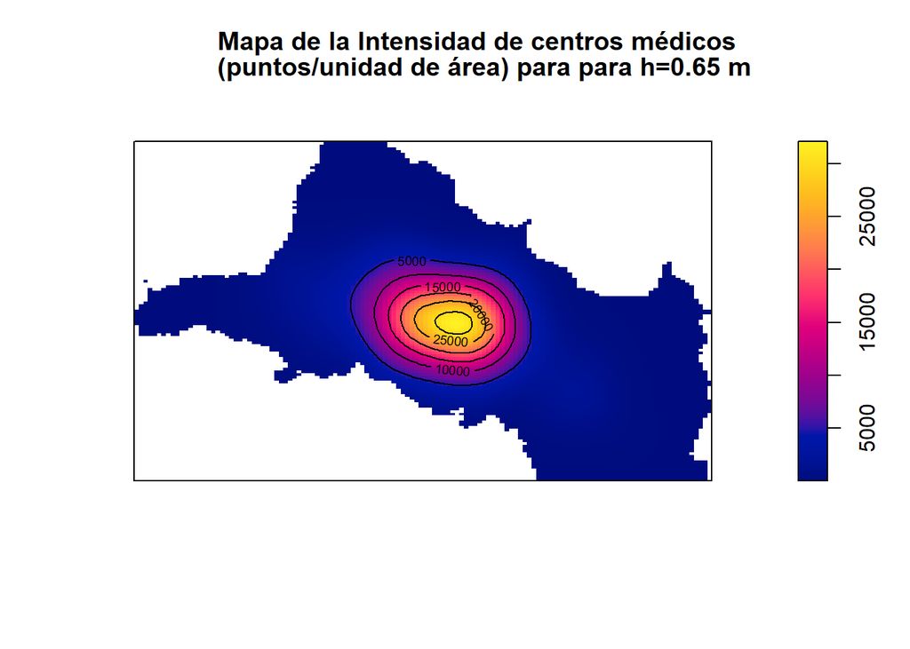

```r
par(mfrow=c(1,1))
K1 <- density(xy.ppp, adjust=0.65) # Using the default bandwidth
plot(K1, main="Mapa de la Intensidad de centros médicos \n (puntos/unidad de área) para para h=0.65 m")
contour(K1, add=TRUE)
```

### Estadísticas de resumen de segundo orden

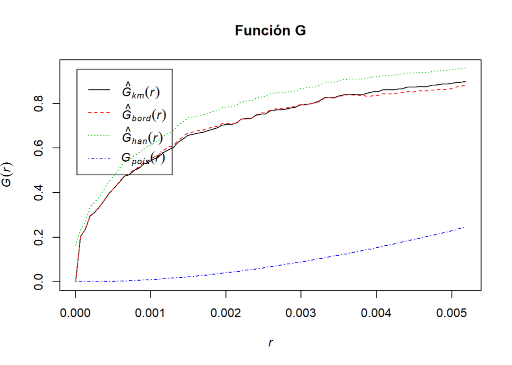

```r
plot(Gest(xy.ppp),main="Función G")
```

La línea calculada a partir de los datos está por encima de la línea azul, esto indica una distribución agrupada.

### Funcionss K y F

```r
K <- Kest(xy.ppp)
K
```

```
  Function value object (class 'fv')
  for the function r -> K(r)
  ....................................................................
         Math.label       Description
  r      r                distance argument r
  theo   K[pois](r)       theoretical Poisson K(r)
  border hat(K)[bord](r)  border-corrected estimate of K(r)
  trans  hat(K)[trans](r) translation-corrected estimate of K(r)
  iso    hat(K)[iso](r)   Ripley isotropic correction estimate of K(r)
  ....................................................................
  Default plot formula:  .~r
  where "." stands for 'iso', 'trans', 'border', 'theo'
  Recommended range of argument r: [0, 0.1041]
  Available range of argument r: [0, 0.1041]
```

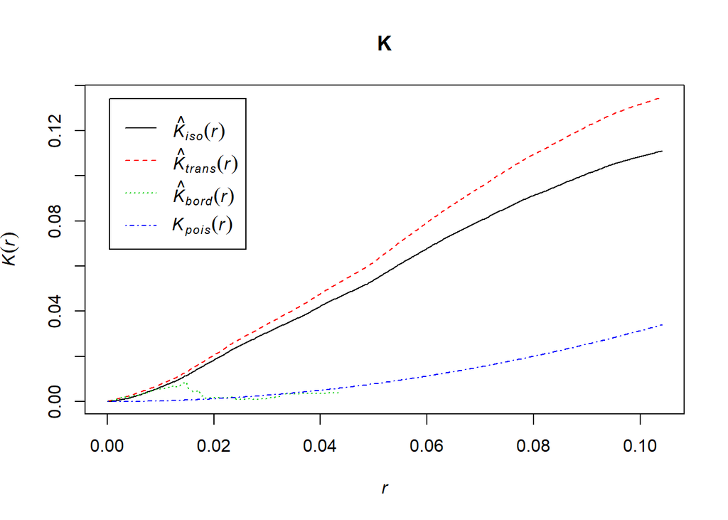

```r
plot(K)
```

```r
F.prueba <- Fest(xy.ppp)
F.prueba
```

```
  Function value object (class 'fv')
  for the function r -> F(r)
  .....................................................................
          Math.label      Description
  r       r               distance argument r
  theo    F[pois](r)      theoretical Poisson F(r)
  cs      hat(F)[cs](r)   Chiu-Stoyan estimate of F(r)
  rs      hat(F)[bord](r) border corrected estimate of F(r)
  km      hat(F)[km](r)   Kaplan-Meier estimate of F(r)
  hazard  hat(h)[km](r)   Kaplan-Meier estimate of hazard function h(r)
  theohaz h[pois](r)      theoretical Poisson hazard h(r)
  .....................................................................
  Default plot formula:  .~r
  where "." stands for 'km', 'rs', 'cs', 'theo'
  Recommended range of argument r: [0, 0.033343]
  Available range of argument r: [0, 0.033343]
```

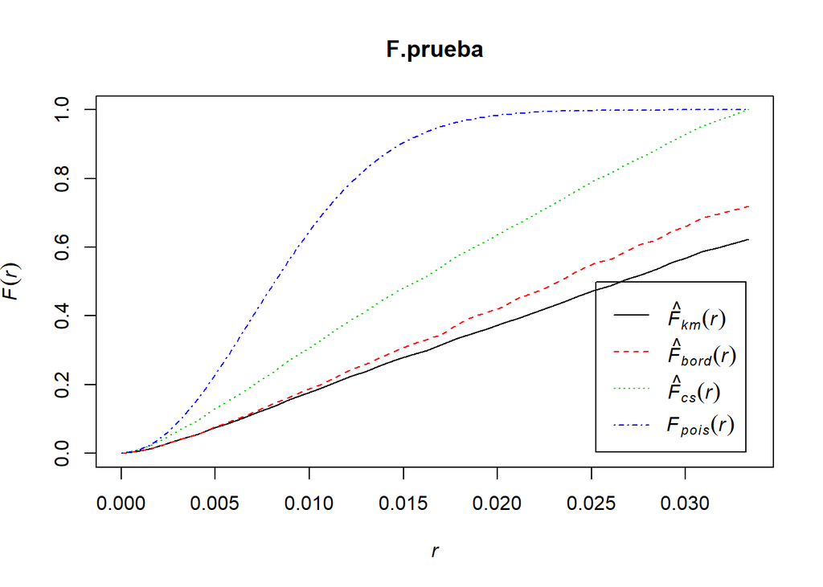

```r
plot(F.prueba)
```

En el caso de la función F, su interpretación es inversa, por lo cual se vuelve a confirmar que las clínicas tienden presentar agrupaciones.

### Estimación de los modelos

#### Modelo Poisson no homogéneo sin la covariable

```r
fit<-ppm(xy.ppp ~ x + y)
fit
```

```
  Nonstationary Poisson process

  Log intensity:  ~x + y

  Fitted trend coefficients:
  (Intercept)           x           y
  -76.9699321  -1.1187962  -0.9037333

                 Estimate       S.E.     CI95.lo     CI95.hi Ztest      Zval
  (Intercept) -76.9699321 23.3524060 -122.739807 -31.2000574   *** -3.296017
  x            -1.1187962  0.3049043   -1.716398  -0.5211947   *** -3.669335
  y            -0.9037333  0.5684116   -2.017799   0.2103329       -1.589928
```

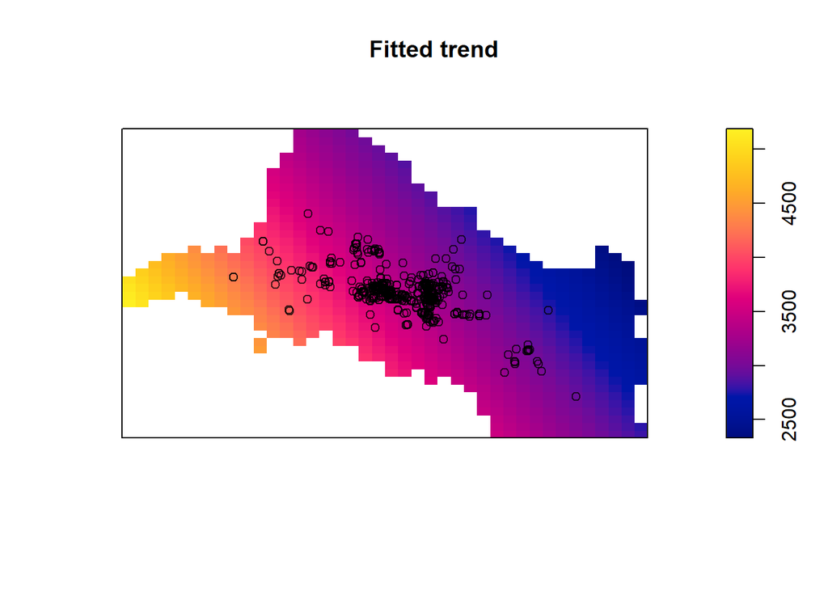

```r
plot(fit, how = "image", se = FALSE, pause = FALSE)
```

#### Modelo Poisson no homogéneo con la covariable

```r
Q <- quadscheme(data=xy.ppp, dummy=list(x=ventana$x, y=ventana$y))
df <- data.frame(distancia=data.clinicas.distancia$distancia)

fit2<-ppm(Q, ~ x + y  + distancia,  covariates=df)
fit2
```

```
  Nonstationary Poisson process

  Log intensity:  ~x + y + distancia

  Fitted trend coefficients:
    (Intercept)             x             y     distancia
  -3.802466e+02 -5.657786e+00 -8.575002e+00 -2.758755e-04

                   Estimate         S.E.       CI95.lo       CI95.hi Ztest
  (Intercept) -3.802466e+02 6.085884e+01 -4.995277e+02 -2.609654e+02   ***
  x           -5.657786e+00 8.785288e-01 -7.379670e+00 -3.935901e+00   ***
  y           -8.575002e+00 1.641464e+00 -1.179221e+01 -5.357792e+00   ***
  distancia   -2.758755e-04 1.870675e-05 -3.125401e-04 -2.392110e-04   ***
                    Zval
  (Intercept)  -6.248009
  x            -6.440069
  y            -5.223997
  distancia   -14.747377
```

#### Modelo Poisson únicamente con la covariable

```r
fit3<-ppm(Q, ~ distancia,  covariates=df)
fit3
```

```
  Nonstationary Poisson process

  Log intensity:  ~distancia

  Fitted trend coefficients:
    (Intercept)     distancia
  10.0444942252 -0.0002247438

                   Estimate         S.E.       CI95.lo       CI95.hi Ztest
  (Intercept) 10.0444942252 7.352825e-02  9.9003814965 10.1886069539   ***
  distancia   -0.0002247438 1.563369e-05 -0.0002553853 -0.0001941023   ***
                   Zval
  (Intercept) 136.60727
  distancia   -14.37561
```

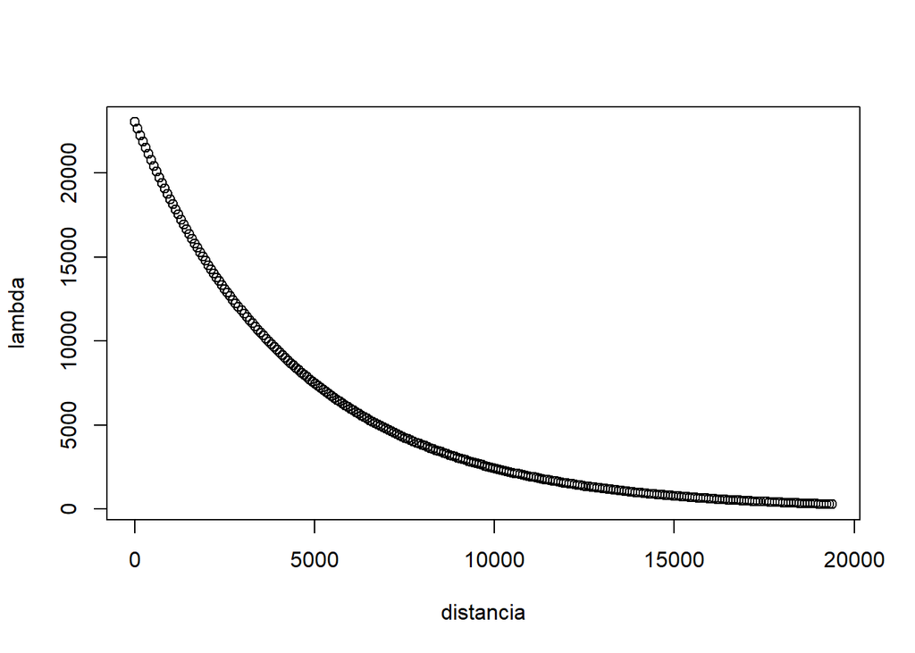

```r
plot(effectfun(fit3, "distancia"), main = "")
```

#### Modelo Poisson homogéneo

Modelo nulo

```r
fitnull <- update(fit, ~1)
fitnull
```

```
  Stationary Poisson process
  Intensity: 3329.042
              Estimate       S.E.  CI95.lo  CI95.hi Ztest     Zval
  log(lambda)  8.11044 0.04526787 8.021717 8.199163   *** 179.1655
```

#### Pruebas de Razón de Verosimilitud

```r
anova(fitnull, fit, test = "Chi") # Mejor modelo con x y y
```

```
  Analysis of Deviance Table

  Model 1: ~1    Poisson
  Model 2: ~x + y    Poisson
    Npar Df Deviance Pr(>Chi)
  1    1
  2    3  2   13.276  0.00131 **
  ---
  Signif. codes:  0 '***' 0.001 '**' 0.01 '*' 0.05 '.' 0.1 ' ' 1
```

```r
anova(fit3, fit2, test = "Chi") # Mejor modelo con la covariable
```

```
  Analysis of Deviance Table

  Model 1: ~distancia    Poisson
  Model 2: ~x + y + distancia    Poisson
    Npar Df Deviance  Pr(>Chi)
  1    2
  2    4  2   45.482 1.329e-10 ***
  ---
  Signif. codes:  0 '***' 0.001 '**' 0.01 '*' 0.05 '.' 0.1 ' ' 1
```

### Modelo seleccionado

Modelo Poisson no homogéneo con la covariable

$\lambda(x;y)=e^{-380.24-5.66 x-8.58 y-0.000276 Z}$

donde Z representa: la distancia (m) de cada centro médico al hospital público más cercano.

### Conclusiones

- La mayoría de centros médicos están agrupados en la provincia de San José.
- En general, las ubicaciones donde se encuentran los hospitales públicos, tienden a presentar centros médicos cercanos.
- Las estadísticas de resumen de segundo orden (funcionse G, K y F), concuerda con que no existe homogeneidad en la distribución espacial de las clínicas y consultorios médicos, es decir presentan agrupaciones.
- La existencia de los centros médicos está relacionado con las coordenadas de latitud y longitud, es decir no son un evento homogéneo.
- No se rechaza la hipótesis de investigación de que la existencia de clínicas y consultorios médicos está relacionada con la cercanía de las mismas a hospitales públicos.